# Analyse du risque pour le Tchad

Dernière mise à jour 2022-01-05

Ce rapport présente une exploration sommaire des risques et vulnérabilités humanitaries au Tchad. Des données sont compilées et présentées sur ces sujets:

- [Analyse ICA](https://geonode.wfp.org/layers/geonode%3Atcd_ica_categories_areas_geonode_mar2017)
- [Risque d’inondations](https://geonode.wfp.org/layers/geonode%3Atcd_ica_floodrisk_geonode_mar2017)
- [Risque de sécheresse](https://geonode.wfp.org/layers/geonode%3Atcd_ica_droughtrisk_geonode_mar2017)
- [Risque de chocs naturels](https://geonode.wfp.org/layers/geonode%3Atcd_ica_naturalshocksrisk_geonode_mar2017)
- [Population](https://data.humdata.org/dataset/population-statistics-of-chad)
- [Personnes déplacées à l’interne](https://data.humdata.org/dataset/population-au-tchad-et-total-idps-retournes-refugies-sadd)
- [Sécurité alimentaire](https://data.humdata.org/dataset/cadre-harmonise)
- [Pauvreté](https://data.humdata.org/dataset/chad-mpi)
- [Présence opérationnelle](https://data.humdata.org/dataset/chad-operational-presence)
- [Projections de précipitations saisonnières](https://iri.columbia.edu/our-expertise/climate/forecasts/seasonal-climate-forecasts/)

Certaines données sont offertes au niveau Admin 2 (Départements). Dans certains cas, une moyenne pour la Région (Admin 1) a été calculée.

### Carte géographique du pays

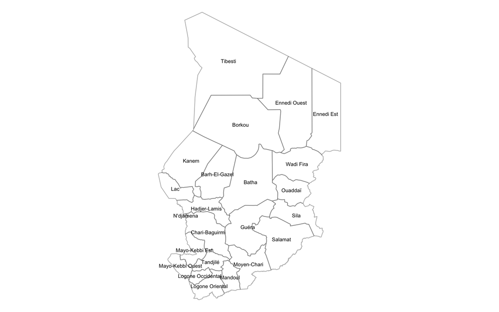

### Sommaire de l’AIC

L’analyse de risques de chocs naturels (sécheresses et inondations) fit partie de l’analyse AIC (“Analyse intégrée du contexte”) conduite par le Programme d’alimentation mondiale. Celle-ci montre les zones de haute convergence entre la récurrence de l’insécurité alimentaire et la propension aux chocs naturels (inondations, sécheresses, glissements de terrain).

[figure not shown]

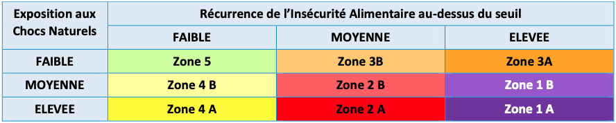

On peut lire le [rapport ici](https://geonode.wfp.org/documents/8911). La liste complète des classifications est en annexe.

### Cartes de facteurs clé

Les régions les plus affectées par les sécheresses et par les inondations diffèrent. Par conséquent le risque de chocs naturels recouvre une vaste partie du territoire. La région de Lac comprend le plus grand nombre de personne en insécurité alimentaire malgré le fait qu’elle ne soit pas la plus populeuse. Les données sur les chocs naturels et l’insécurité alimentaires ne couvrent pas une période ajacente. Une analyse additionnelle sera nécessaire pour comprendre le lien entre les chocs et la présence de choc.

La région de Lac fut la seule récipiendaire d’activités humanitaires reportées en juin 2020. Elle est la région avec l’index multidimensionnel de pauvreté le plus élevé du pays et reçoit un des plus grands nombres de personnes déplacées internes après Ouaddaï.

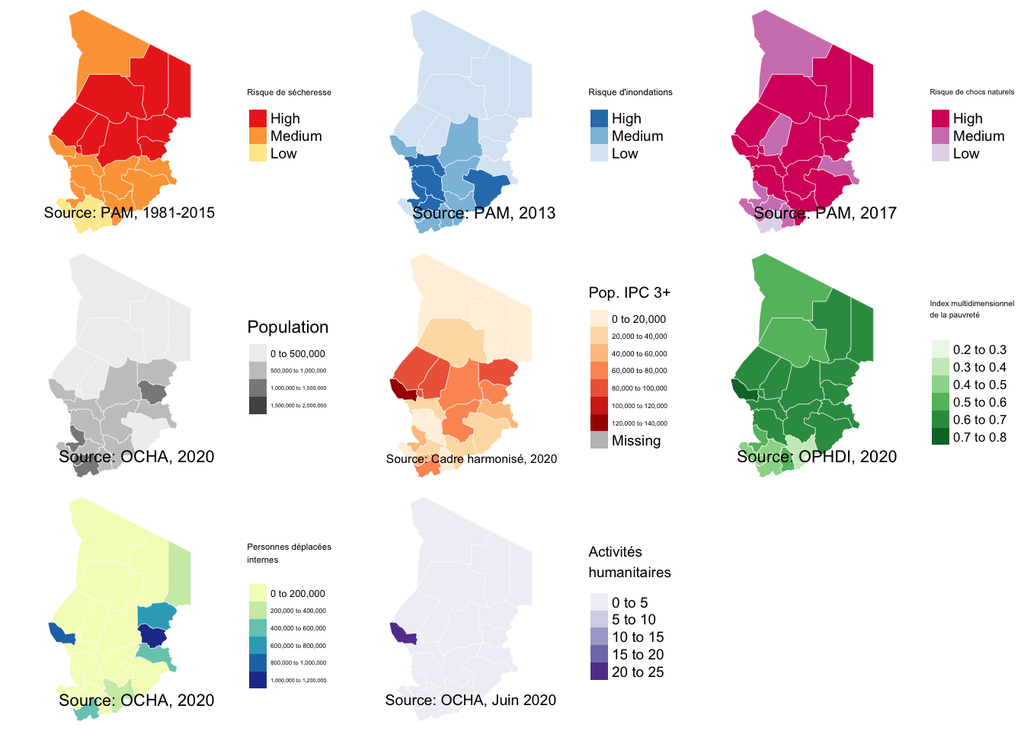

### Données en format tabulaire

Risques, vulnérabliités et facteurs de capacité par Région

| Région | Risque sécheresse | Risque inondations | Risque chocs naturels | Population | IPC Phase 3+ | Index multidimensionnel pauvreté | PDIs | Activités humanitaires |
| --- | --- | --- | --- | --- | --- | --- | --- | --- |
| Barh-El-Gazel | High | Low | Medium | 373443 | 82852 | 0.6528102 | 0 | 0 |
| Batha | High | Medium | High | 689837 | 68415 | 0.6467541 | 0 | 0 |
| Borkou | High | Low | High | 138102 | 35113 | 0.5347672 | 0 | 0 |
| Chari-Baguirmi | Medium | High | High | 845088 | 11835 | 0.6324500 | 0 | 0 |
| Ennedi Est | High | Low | High | 158098 | 8884 | 0.6271685 | 208299 | 0 |
| Ennedi Ouest | High | Low | High | 89315 | 6046 | 0.6271685 | 947 | 0 |
| Guéra | Medium | Medium | High | 635819 | 78064 | 0.6078924 | 0 | 0 |
| Hadjer-Lamis | Medium | High | High | 822224 | 35996 | 0.6320465 | 0 | 0 |
| Kanem | High | Low | High | 498268 | 97865 | 0.6751763 | 0 | 0 |
| Lac | Medium | Medium | High | 638662 | 121825 | 0.7107827 | 932314 | 22 |
| Logone Occidental | Low | Medium | Medium | 1032538 | 58135 | 0.4161822 | 0 | 0 |
| Logone Oriental | Low | Medium | Low | 1161150 | 74874 | 0.4830830 | 565643 | 0 |
| Mandoul | Low | Medium | Medium | 928310 | 17896 | 0.5172537 | 88880 | 0 |
| Mayo-Kebbi Est | Medium | High | Medium | 1146679 | 41683 | 0.5103123 | 8817 | 0 |
| Mayo-Kebbi Ouest | Low | Low | Medium | 845398 | 15247 | 0.4775945 | 0 | 0 |
| Moyen-Chari | Medium | Medium | High | 877779 | 36330 | 0.3891789 | 311030 | 0 |
| N’djamena | Medium | High | High | 1592258 | NA | 0.2290149 | 37233 | 0 |
| Ouaddaï | High | Low | High | 1068951 | 65182 | 0.6599181 | 1101675 | 0 |
| Salamat | Medium | High | High | 450500 | 24968 | 0.6549829 | 52247 | 0 |
| Sila | Medium | Low | Medium | 563716 | 52065 | 0.6858500 | 581182 | 0 |
| Tandjilé | Low | High | Medium | 996198 | 37443 | 0.4601206 | 0 | 0 |
| Tibesti | Medium | Low | Medium | 37783 | 8249 | 0.5347672 | 0 | 0 |
| Wadi Fira | High | Low | High | 754735 | 94516 | 0.6970032 | 769825 | 0 |

### Prévisions de précipitations

Les prévisions de l’[IRI](https://iri.columbia.edu/our-expertise/climate/forecasts/seasonal-climate-forecasts/) les plus récentes projettent une saison des pluies avec un cumul de précipitations au-delà de la normale pour la majeure partie du pays, et une saison en-deçà de la normale dans le sud est.

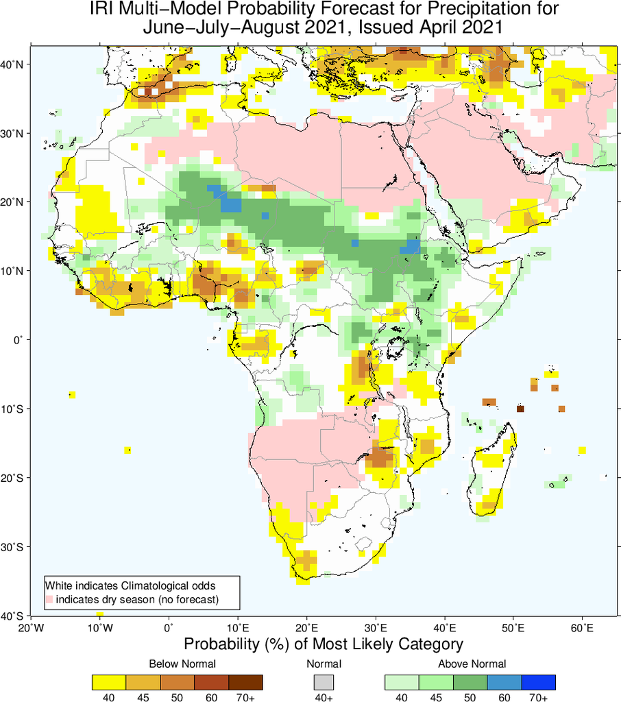

### Annexe

Résultats de l’analyse intégrée du contexte.

Analyse intégrée du contexte au Tchad (2017)

| Région | Département | Aire AIC | Récurrence insécurité alimentaire | Exposition aux chocs naturels |
| --- | --- | --- | --- | --- |
| Barh-El-Gazel | Barh-El-Gazel Nord | Area 1a | Élevée | Élevée |
|  | Barh-El-Gazel Ouest | Area 1b | Élevée | Moyenne |
|  | Barh-El-Gazel Sud | Area 1b | Élevée | Moyenne |
| Batha | Batha Est | Area 1a | Élevée | Élevée |
|  | Batha Ouest | Area 1a | Élevée | Élevée |
|  | Fitri | Area 1a | Élevée | Élevée |
| Borkou | Borkou | Area 4a | Faible | Élevée |
|  | Borkou Yala | Area 4a | Faible | Élevée |
| Chari-Baguirmi | Baguirmi | Area 4a | Faible | Élevée |
|  | Chari | Area 4a | Faible | Élevée |
|  | Loug-Chari | Area 4a | Faible | Élevée |
| Ennedi Est | Am-Djarass | Area 2a | Moyenne | Élevée |
|  | Wadi Hawar | Area 2a | Moyenne | Élevée |
| Ennedi Ouest | Fada | Area 4a | Faible | Élevée |
|  | Mourtcha | Area 4a | Faible | Élevée |
| Guéra | Abtouyour | Area 1a | Élevée | Élevée |
|  | Barh-Signaka | Area 2a | Moyenne | Élevée |
|  | Guéra | Area 1a | Élevée | Élevée |
|  | Mangalmé | Area 2a | Moyenne | Élevée |
| Hadjer-Lamis | Dababa | Area 4a | Faible | Élevée |
|  | Dagana | Area 4a | Faible | Élevée |
|  | Haraze-Al-Biar | Area 4a | Faible | Élevée |
| Kanem | Kanem | Area 1a | Élevée | Élevée |
|  | Nord Kanem | Area 1a | Élevée | Élevée |
|  | Wadi Bissam | Area 2a | Moyenne | Élevée |
| Lac | Fouli | NA | Faible | Faible |
|  | Kaya | NA | Faible | Faible |
|  | Mamdi | Area 1a | Élevée | Élevée |
|  | Wayi | Area 1a | Élevée | Élevée |
| Logone Occidental | Dodjé | Area 2b | Moyenne | Moyenne |
|  | Guéni | Area 2b | Moyenne | Moyenne |
|  | Lac Wey | Area 3b | Moyenne | Faible |
|  | Ngourkosso | Area 2b | Moyenne | Moyenne |
| Logone Oriental | Kouh Est | Area 1b | Élevée | Moyenne |
|  | Kouh Ouest | Area 3b | Moyenne | Faible |
|  | La Nya | Area 2b | Moyenne | Moyenne |
|  | La Nya Pendé | Area 3a | Élevée | Faible |
|  | La Pendé | Area 2b | Moyenne | Moyenne |
|  | Monts de Lam | Area 3b | Moyenne | Faible |
| Mandoul | Barh-Sara | Area 4b | Faible | Moyenne |
|  | Mandoul Occidental | Area 4b | Faible | Moyenne |
|  | Mandoul Oriental | Area 4b | Faible | Moyenne |
| Mayo-Kebbi Est | Kabbia | Area 2b | Moyenne | Moyenne |
|  | Mayo-Boneye | Area 4b | Faible | Moyenne |
|  | Mayo-Lemié | Area 2a | Moyenne | Élevée |
|  | Mont Illi | Area 2b | Moyenne | Moyenne |
| Mayo-Kebbi Ouest | Lac Léré | Area 2b | Moyenne | Moyenne |
|  | Mayo-Binder | Area 2b | Moyenne | Moyenne |
|  | Mayo-Dallah | Area 3b | Moyenne | Faible |
| Moyen-Chari | Bahr-Köh | Area 2a | Moyenne | Élevée |
|  | Grande Sido | Area 4b | Faible | Moyenne |
|  | Lac Iro | Area 4a | Faible | Élevée |
| N’Djamena | N’Djaména | Uncategorized | Faible | Faible |
| Ouaddaï | Abdi | Area 2b | Moyenne | Moyenne |
|  | Assoungha | Area 1a | Élevée | Élevée |
|  | Ouara | Area 2a | Moyenne | Élevée |
| Salamat | Aboudéia | Area 2a | Moyenne | Élevée |
|  | Bahr-Azoum | Area 4a | Faible | Élevée |
|  | Haraze-Mangueigne | Area 4b | Faible | Moyenne |
| Sila | Djourf Al Ahmar | Area 2b | Moyenne | Moyenne |
|  | Kimiti | Area 2b | Moyenne | Moyenne |
| Tandjilé | Tandjilé Centre | Area 2b | Moyenne | Moyenne |
|  | Tandjilé Est | Area 2b | Moyenne | Moyenne |
|  | Tandjile Ouest | Area 4b | Faible | Moyenne |
| Tibesti | Tibesti Est | Area 5 | Faible | Faible |
|  | Tibesti Ouest | Area 4a | Faible | Élevée |
| Wadi Fira | Biltine | Area 1a | Élevée | Élevée |
|  | Dar-Tama | Area 1a | Élevée | Élevée |
|  | Kobé | NA | Faible | Faible |
|  | Mégri | Area 1a | Élevée | Élevée |